# PCA Analysis of The World Happiness Report 2017 Data

João Cláudio Macosso

2023-02-25

# Introduction

Principal Component Analysis (PCA) is a widely used data analysis technique that can be applied to a range of fields and applications. In this report I will conduct PCA to perform dimension reduction of the World Happiness Report 2017, an annual survey that ranks countries according to their level of happiness and well-being. The 2017 edition of the report contains a wealth of data on a range of factors that contribute to happiness, including economic, social, and political factors. By applying PCA to this dataset, it is possible to identify the key factors that contribute to happiness and well-being across different countries and regions. # Load Libraries

```r
library(tidyverse)
library(factoextra)
library(flexclust)
library(fpc)
library(clustertend)
library(cluster)
library(ClusterR)
library(ggplot2)
library(DALEX)
library(ggpubr)
library(ClusterR)
library(fastDummies)
library(qdapTools)
library(gridExtra)
library(corrplot)
library(psych)
library(reshape2)
library(scales)
```

# EDA

```r
Happiness_Report <- read_csv("Data/World Happiness Report/2017.csv")
Happiness_Report
```

| Country | Happiness.Rank | Happiness.Score | Whisker.high | Whisker.low | Economy..GDP.per.Capita. | Family | Health..Life.Expectancy. | Freedom | Generosity | Trust..Government.Corruption. | Dystopia.Residual |
| --- | --- | --- | --- | --- | --- | --- | --- | --- | --- | --- | --- |
| Norway | 1 | 7.537 | 7.594445 | 7.479556 | 1.61646318 | 1.5335236 | 0.796666503 | 0.63542259 | 0.36201224 | 0.315963835 | 2.2770267 |
| Denmark | 2 | 7.522 | 7.581728 | 7.462272 | 1.48238301 | 1.5511216 | 0.792565525 | 0.62600672 | 0.35528049 | 0.400770068 | 2.3137074 |
| Iceland | 3 | 7.504 | 7.622030 | 7.385970 | 1.48063302 | 1.6105740 | 0.833552122 | 0.62716264 | 0.47554022 | 0.153526559 | 2.3227153 |
| Switzerland | 4 | 7.494 | 7.561772 | 7.426227 | 1.56497955 | 1.5169117 | 0.858131289 | 0.62007058 | 0.29054928 | 0.367007285 | 2.2767162 |
| Finland | 5 | 7.469 | 7.527542 | 7.410458 | 1.44357193 | 1.5402467 | 0.809157670 | 0.61795086 | 0.24548277 | 0.382611543 | 2.4301815 |
| Netherlands | 6 | 7.377 | 7.427426 | 7.326574 | 1.50394464 | 1.4289392 | 0.810696125 | 0.58538449 | 0.47048983 | 0.282661825 | 2.2948041 |
| Canada | 7 | 7.316 | 7.384403 | 7.247597 | 1.47920442 | 1.4813490 | 0.834557652 | 0.61110091 | 0.43553972 | 0.287371516 | 2.1872644 |
| New Zealand | 8 | 7.314 | 7.379510 | 7.248490 | 1.40570605 | 1.5481951 | 0.816759706 | 0.61406213 | 0.50000513 | 0.382816702 | 2.0464563 |
| Sweden | 9 | 7.284 | 7.344095 | 7.223905 | 1.49438727 | 1.4781622 | 0.830875158 | 0.61292410 | 0.38539925 | 0.384398729 | 2.0975380 |
| Australia | 10 | 7.284 | 7.356651 | 7.211349 | 1.48441494 | 1.5100420 | 0.843886793 | 0.60160738 | 0.47769925 | 0.301183730 | 2.0652108 |

[output cut: 145 more lines]

We can delete the columns(“Country”, “Happiness.Rank”, “Whisker.high”, “Whisker.low”)

```r
Happiness <- Happiness_Report %>%
  select(-c(Country, Happiness.Rank, Whisker.high, Whisker.low))
Happiness
```

| Happiness.Score | Economy..GDP.per.Capita. | Family | Health..Life.Expectancy. | Freedom | Generosity | Trust..Government.Corruption. | Dystopia.Residual |
| --- | --- | --- | --- | --- | --- | --- | --- |
| 7.537 | 1.61646318 | 1.5335236 | 0.796666503 | 0.63542259 | 0.36201224 | 0.315963835 | 2.2770267 |
| 7.522 | 1.48238301 | 1.5511216 | 0.792565525 | 0.62600672 | 0.35528049 | 0.400770068 | 2.3137074 |
| 7.504 | 1.48063302 | 1.6105740 | 0.833552122 | 0.62716264 | 0.47554022 | 0.153526559 | 2.3227153 |
| 7.494 | 1.56497955 | 1.5169117 | 0.858131289 | 0.62007058 | 0.29054928 | 0.367007285 | 2.2767162 |
| 7.469 | 1.44357193 | 1.5402467 | 0.809157670 | 0.61795086 | 0.24548277 | 0.382611543 | 2.4301815 |
| 7.377 | 1.50394464 | 1.4289392 | 0.810696125 | 0.58538449 | 0.47048983 | 0.282661825 | 2.2948041 |
| 7.316 | 1.47920442 | 1.4813490 | 0.834557652 | 0.61110091 | 0.43553972 | 0.287371516 | 2.1872644 |
| 7.314 | 1.40570605 | 1.5481951 | 0.816759706 | 0.61406213 | 0.50000513 | 0.382816702 | 2.0464563 |
| 7.284 | 1.49438727 | 1.4781622 | 0.830875158 | 0.61292410 | 0.38539925 | 0.384398729 | 2.0975380 |
| 7.284 | 1.48441494 | 1.5100420 | 0.843886793 | 0.60160738 | 0.47769925 | 0.301183730 | 2.0652108 |

[output cut: 145 more lines]

## Scale the Data

Scaling the data is an essential preprocessing step in PCA. The reason is that PCA is a variance-maximizing exercise, which means that it will identify the directions of maximum variance in the data. When data is not scaled, variables with higher variances will dominate the analysis, regardless of their importance in explaining the underlying structure of the data. By scaling the data, we ensure that each variable has equal importance in the analysis, which is crucial for correctly identifying the directions of maximum variance. Scaling also helps to avoid numerical problems that can arise when working with variables that have different scales or units of measurement. Overall, scaling is an important step in PCA that allows us to extract meaningful information from the data and make reliable inferences about the underlying structure of the variables.

```r
Happiness_scaled <- center_scale(Happiness)
colnames(Happiness_scaled) <- colnames(Happiness)
head(Happiness_scaled)
```

```
##      Happiness.Score Economy..GDP.per.Capita.   Family Health..Life.Expectancy.
## [1,]        1.929741                 1.501321 1.199688                 1.034812
## [2,]        1.916481                 1.182684 1.260949                 1.017514
## [3,]        1.900569                 1.178525 1.467911                 1.190400
## [4,]        1.891729                 1.378972 1.141860                 1.294078
## [5,]        1.869629                 1.090451 1.223092                 1.087501
## [6,]        1.788302                 1.233924 0.835616                 1.093991
##       Freedom  Generosity Trust..Government.Corruption. Dystopia.Residual
## [1,] 1.510938  0.85419543                     1.8969355         0.8535293
## [2,] 1.448164  0.80424936                     2.7311448         0.9268865
## [3,] 1.455871  1.69651389                     0.2990966         0.9449014
## [4,] 1.408589  0.32397752                     2.3990321         0.8529085
## [5,] 1.394458 -0.01039246                     2.5525258         1.1598216
## [6,] 1.177345  1.65904262                     1.5693552         0.8890821
```

## Distribution of the variables

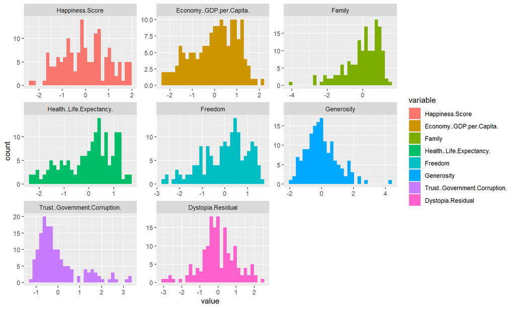

```r
happy_long <- melt(data.frame(Happiness_scaled), id.vars = NULL)

ggplot(data = happy_long, aes(x = value, fill = variable)) +
  geom_histogram() +
  theme(plot.title = element_text(hjust = 0.5, size = 15)) +
  facet_wrap(.~ variable, scales = "free", ncol = 3)
```

## Correlation Matrix

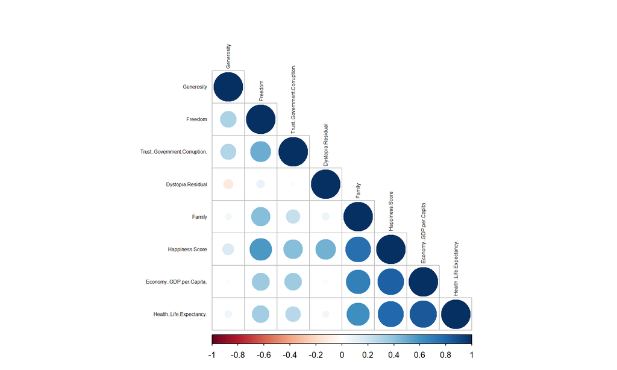

```r
cor_mat <- cor(Happiness)
corrplot(cor_mat, type = "lower", order = "hclust",
         tl.col = "black", tl.cex = 0.5)
```

# Principal Component Analysis (PCA)

Principal Component Analysis (PCA) is a method used to decrease the complexity of data by reducing its dimensionality. This allows for easier interpretation while minimizing the amount of information lost. PCA achieves this by generating new variables that are not correlated with each other, while also maximizing the amount of variance present in the data.

```r
happ_pca <- prcomp(Happiness, center = TRUE, scale = TRUE)
summary(happ_pca)
```

```
## Importance of components:
##                           PC1    PC2    PC3     PC4     PC5     PC6     PC7
## Standard deviation     1.9564 1.1812 1.0409 0.81890 0.72606 0.59984 0.36887
## Proportion of Variance 0.4785 0.1744 0.1354 0.08382 0.06589 0.04498 0.01701
## Cumulative Proportion  0.4785 0.6529 0.7883 0.87212 0.93802 0.98299 1.00000
##                              PC8
## Standard deviation     0.0002029
## Proportion of Variance 0.0000000
## Cumulative Proportion  1.0000000
```

## Choosing number of components

There are 3 most common methods used to select the number of components: The Kaiser Rule, Cree plot, Proportion of Variance explained

### The Kaiser Rule

The Kaiser rule is a commonly used method for determining the number of components to retain in PCA. It focuses on the eigenvalues of each component, which represent the amount of variance explained by that component. The Kaiser rule suggests that only components with eigenvalues greater than 1 should be retained, as eigenvalues less than 1 indicate that the component explains less variance than a single variable. This approach is based on the idea that components with eigenvalues greater than 1 are more meaningful and contain more information than those with eigenvalues less than 1.

```r
eig.val <- get_eigenvalue(happ_pca)
round(eig.val,3)
```

|  | eigenvalue | variance.percent | cumulative.variance.percent |
| --- | --- | --- | --- |
| Dim.1 | 3.828 | 47.846 | 47.846 |
| Dim.2 | 1.395 | 17.441 | 65.287 |
| Dim.3 | 1.083 | 13.543 | 78.830 |
| Dim.4 | 0.671 | 8.382 | 87.212 |
| Dim.5 | 0.527 | 6.589 | 93.802 |
| Dim.6 | 0.360 | 4.498 | 98.299 |
| Dim.7 | 0.136 | 1.701 | 100.000 |
| Dim.8 | 0.000 | 0.000 | 100.000 |

Based on the table above we can see that the components 1, 2, and 3 have eigen values higher than 1, thus only those components should be chosen.

### Scree plot

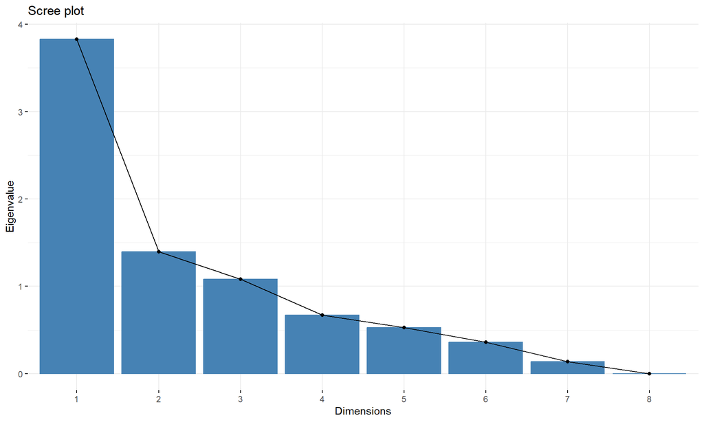

```r
fviz_eig(happ_pca, choice='eigenvalue')
```

This approach, as well as the Kaiser rule, indicates that the right number of components is 3.

### Proportion of variance explained

The number of components can be determined based on the amount of variance explained by each component. This method suggests that chosen components should explain over 2/3 of the variance.

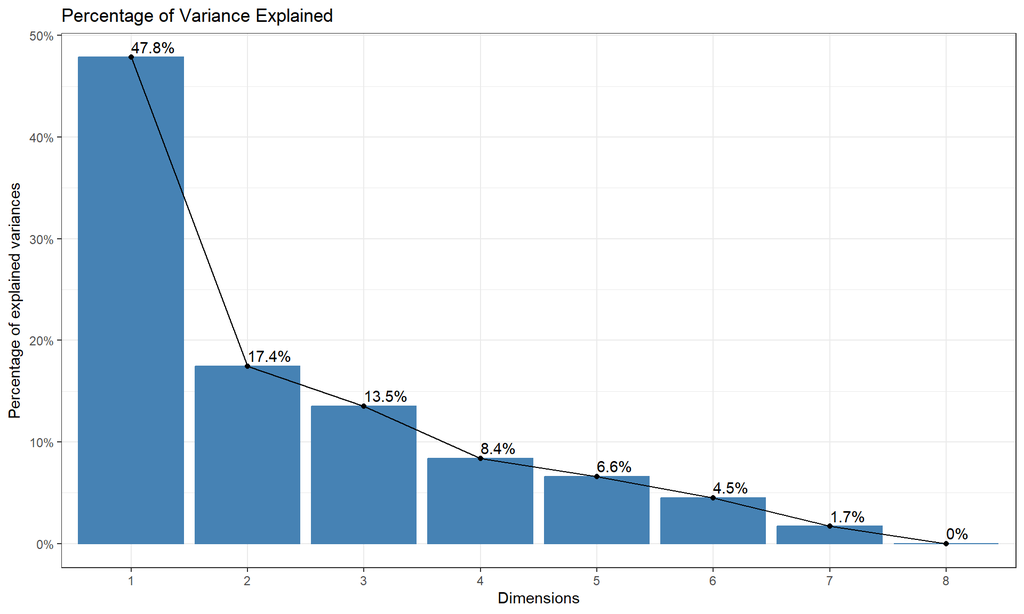

```r
fviz_eig(happ_pca, choice='variance', addlabels = T)+
  scale_y_continuous(breaks = seq(0, 100, by = 10),
                     labels = paste0(format(seq(0, 100, by = 10)),"%")) +
  labs(title = "Percentage of Variance Explained") +
  theme_bw()
```

The plot above shows that the component 1 explains 47.8% of Variance, the component 17.4% of variance and component 13.5% of variance.

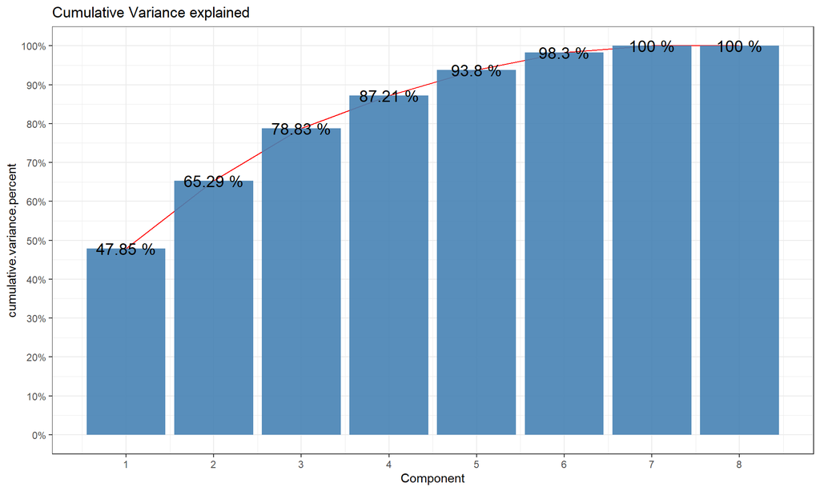

```r
pca_df <- data.frame(eig.val)
pca_df$Component <- rownames(pca_df)

pca_df %>%
  mutate(Component = substr(Component, 5,6),
         Component = as.numeric(Component)) %>%
ggplot(aes(x = Component,
           y = cumulative.variance.percent)) +
  geom_line(col = "red") +
  geom_bar(stat = "identity", fill = "steelblue", width = .9, alpha = 0.9)+
  scale_y_continuous(breaks = seq(0, 100, by = 10),
                     labels = paste0(format(seq(0, 100, by = 10)),"%")) +
  scale_x_continuous(n.breaks = 8) +
  geom_text(aes(label = paste(round(cumulative.variance.percent,2),"%")),
            size = 5) +
  expand_limits(y = 0)+
  labs(title = "Cumulative Variance explained") +
  theme_bw()
```

With the cummulative variance above, we can see that the components 1,2,3 have a cumulative variance of 78.8% which is already well above 2/3 of total variance. limitting our analysis to just these 3 components would help avoiding overfitting.